# LiveSessionAssignment06: Rolling Sales for Manhattan

Christopher Donlan, Rajni Goyal, and Justin Beer

October 14, 2016

```r
getwd()
```

```
## [1] "C:/Users/rgoyal/Desktop/MS-Data Science/Data Science/Live Session Assignments/Live Session Assignment-6"
```

```r
mh <- read.csv("rollingsales_manhattan.csv",skip=4,header=TRUE)

head(mh)
```

```
##   BOROUGH              NEIGHBORHOOD
## 1       1 ALPHABET CITY
## 2       1 ALPHABET CITY
## 3       1 ALPHABET CITY
## 4       1 ALPHABET CITY
## 5       1 ALPHABET CITY
## 6       1 ALPHABET CITY
##                        BUILDING.CLASS.CATEGORY TAX.CLASS.AT.PRESENT BLOCK
## 1 01  ONE FAMILY DWELLINGS                                        1   390
## 2 03  THREE FAMILY DWELLINGS                                      1   376
## 3 07  RENTALS - WALKUP APARTMENTS                                2B   373
## 4 07  RENTALS - WALKUP APARTMENTS                                2B   373
## 5 07  RENTALS - WALKUP APARTMENTS                                 2   377
## 6 07  RENTALS - WALKUP APARTMENTS                                 2   377
##   LOT EASE.MENT BUILDING.CLASS.AT.PRESENT
```

[output cut: 34 more lines]

```r
summary(mh)
```

```
##     BOROUGH                     NEIGHBORHOOD
##  Min.   :1   MIDTOWN WEST             : 4718
##  1st Qu.:1   UPPER EAST SIDE (59-79)  : 2037
##  Median :1   UPPER EAST SIDE (79-96)  : 1671
##  Mean   :1   UPPER WEST SIDE (59-79)  : 1575
##  3rd Qu.:1   MIDTOWN EAST             : 1399
##  Max.   :1   UPPER WEST SIDE (79-96)  : 1034
##              (Other)                  :10369
##                                  BUILDING.CLASS.CATEGORY
##  13  CONDOS - ELEVATOR APARTMENTS            :7807
##  10  COOPS - ELEVATOR APARTMENTS             :6144
##  45  CONDO HOTELS                            :2504
##  26  OTHER HOTELS                            :1457
##  17  CONDO COOPS                             :1006
##  07  RENTALS - WALKUP APARTMENTS             : 783
##  (Other)                                     :3102
##  TAX.CLASS.AT.PRESENT     BLOCK           LOT         EASE.MENT
##  2      :16117        Min.   :   5   Min.   :   1.0   Mode:logical
##  4      : 5124        1st Qu.: 861   1st Qu.:  37.0   NA's:22803
##  2C     :  583        Median :1044   Median :1010.0
##  1      :  339        Mean   :1105   Mean   : 787.1
##  2B     :  276        3rd Qu.:1410   3rd Qu.:1302.0
##  2A     :  186        Max.   :2250   Max.   :9139.0
##  (Other):  178
##  BUILDING.CLASS.AT.PRESENT
##  R4     :7697
##  D4     :5914
##  RH     :2504
##  H3     :1440
##  R9     :1006
##  C6     : 762
##  (Other):3480
##                                       ADDRESS          APARTMENT.NUMBER
##  1335 AVENUE OF THE AMERIC                : 1777               :11549
##  102 WEST 57TH STREET                     : 1325   HU2         : 1236
##  1335 AVENUE OF THE AMER                  :  443   TIMES       :  987
##  200 EAST 94TH   STREET                   :  249   5A          :   87
##  50 RIVERSIDE BOULEVARD                   :  173   3A          :   86
##  301 WEST 53RD   STREET                   :  145   4A          :   78
##  (Other)                                  :18691   (Other)     : 8780
```

[output cut: 17 more lines]

```
##  Min.   :1.000             R4     :7807
##  1st Qu.:2.000             D4     :5914
##  Median :2.000             RH     :2504
##  Mean   :2.438             H3     :1441
##  3rd Qu.:2.000             R9     :1006
##  Max.   :4.000             C6     : 762
##                            (Other):3369
##      SALE.PRICE         SALE.DATE
##   -       : 4519   10/28/2015:  354
##  45,000   :  182   11/23/2015:  348
##  10       :   95   12/21/2015:  319
##  1,100,000:   90   7/14/2016 :  286
##  850,000  :   88   1/13/2016 :  267
##  650,000  :   78   6/30/2016 :  255
##  (Other)  :17751   (Other)   :20974
```

```r
str(mh)
```

```
## 'data.frame':    22803 obs. of  21 variables:
##  $ BOROUGH                       : int  1 1 1 1 1 1 1 1 1 1 ...
##  $ NEIGHBORHOOD                  : Factor w/ 39 levels "ALPHABET CITY            ",..: 1 1 1 1 1 1 1 1 1 1 ...
##  $ BUILDING.CLASS.CATEGORY       : Factor w/ 41 levels "01  ONE FAMILY DWELLINGS                    ",..: 1 3 5 5 5 5 5 5 5 5 ...
##  $ TAX.CLASS.AT.PRESENT          : Factor w/ 9 levels "  ","1","1A",..: 2 2 7 7 5 5 5 5 5 5 ...
##  $ BLOCK                         : int  390 376 373 373 377 377 385 387 387 387 ...
##  $ LOT                           : int  61 24 16 17 2 2 2 119 119 119 ...
##  $ EASE.MENT                     : logi  NA NA NA NA NA NA ...
##  $ BUILDING.CLASS.AT.PRESENT     : Factor w/ 122 levels "  ","A1","A4",..: 3 11 12 12 18 18 18 18 18 18 ...
##  $ ADDRESS                       : Factor w/ 11614 levels "1-2 RIVER TERRACE                        ",..: 3134 5488 6904 6922 732 732 3894 10437 10437 10433 ...
##  $ APARTMENT.NUMBER              : Factor w/ 2686 levels "            ",..: 1 1 1 1 1 1 1 1 1 1 ...
##  $ ZIP.CODE                      : int  10009 10009 10009 10009 10009 10009 10009 10009 10009 10009 ...
##  $ RESIDENTIAL.UNITS             : int  1 3 10 10 22 22 12 22 22 22 ...
##  $ COMMERCIAL.UNITS              : int  0 0 0 0 3 3 4 2 2 2 ...
##  $ TOTAL.UNITS                   : int  1 3 10 10 25 25 16 24 24 24 ...
##  $ LAND.SQUARE.FEET              : Factor w/ 1027 levels " -   ","1,003",..: 1026 402 437 437 783 783 751 669 669 669 ...
##  $ GROSS.SQUARE.FEET             : Factor w/ 1457 levels " -   ","1,000",..: 357 674 1332 1332 343 343 65 179 179 179 ...
##  $ YEAR.BUILT                    : int  1860 1900 1899 1900 1900 1900 1900 1920 1920 1920 ...
##  $ TAX.CLASS.AT.TIME.OF.SALE     : int  1 1 2 2 2 2 2 2 2 2 ...
##  $ BUILDING.CLASS.AT.TIME.OF.SALE: Factor w/ 121 levels "A1","A4","A5",..: 2 10 11 11 17 17 17 17 17 17 ...
##  $ SALE.PRICE                    : Factor w/ 6787 levels " -   ","1","1,000",..: 1 3095 2464 1 1665 1 1 1215 1 1 ...
##  $ SALE.DATE                     : Factor w/ 350 levels "1/1/2016","1/10/2016",..: 336 45 70 70 322 322 152 122 122 122 ...
```

```r
## clean/format the data with regular expressions
## More on these later. For now, know that the
## pattern "[^[:digit:]]" refers to members of the variable name that
## start with digits. We use the gsub command to replace them with a blank space.
# We create a new variable that is a "clean' version of sale.price.
# And sale.price.n is numeric, not a factor.
mh$SALE.PRICE.N <- as.numeric(gsub("[^[:digit:]]","", mh$SALE.PRICE))
count(is.na(mh$SALE.PRICE.N))
```

```
##       x  freq
## 1 FALSE 18284
## 2  TRUE  4519
```

```r
names(mh) <- tolower(names(mh)) # make all variable names lower case
## Get rid of leading digits
mh$gross.sqft <- as.numeric(gsub("[^[:digit:]]","", mh$gross.square.feet))
head(mh$gross.sqft)
```

```
## [1]  2183  3696  8625  8625 19830 19830
```

```r
mh$land.sqft <- as.numeric(gsub("[^[:digit:]]","", mh$land.square.feet))
head(mh$land.sqft)
```

```
## [1]  987 2059 2204 2204 4510 4510
```

```r
mh$year.built <- as.numeric(as.character(mh$year.built))
head(mh$year.built)
```

```
## [1] 1860 1900 1899 1900 1900 1900
```

```r
## do a bit of exploration to make sure there's not anything
## weird going on with sale prices
attach(mh)
detach(mh)
## keep only the actual sales
mh.sale <- mh[mh$sale.price.n!=0,]
mh.homes <- mh.sale[which(grepl("FAMILY",mh.sale$building.class.category)),]
```

## Purpose

This document outlines our loading, cleaning, and exploratory analysis of the data for Manhattan rolling home sales.

## Exploratory Data Analysis

Let us now move onto our findings for the exploratory data analysis. We only analyzed the 1, 2, and 3 family homes. First, we will plot these homes as a log10 chart of the Gross Square Footage versus the Sales Price. From this we can see that we have several outliers but that there is also a minor trend showing the possibility of the sales price increasing as the gross square footage increases.

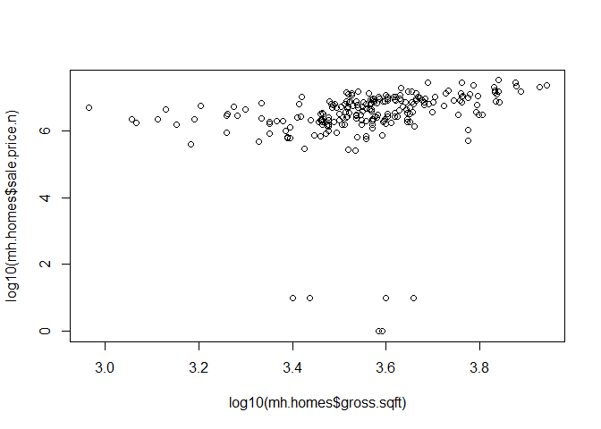

In order to investigate this further, we will now remove the outliers we saw in the log10 plot. After removing the outliers we visualized the data with a natural log plot. Below we can see that there is a clearer trend of increasing sales price as the gross square footage increases as compared to the log10 plot.

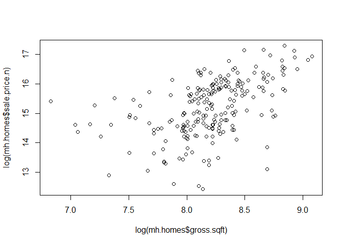

Now that we have removed the outliers lets look at a simple plot of the gross square footage versus the sales price:

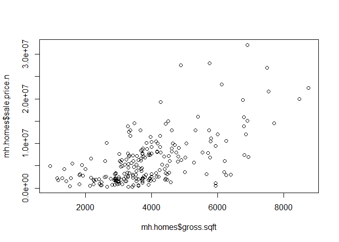

While the above plot shows our trend lets move onto adding a line of best fit, box plots, and standard deviation bands to best visualize this data:

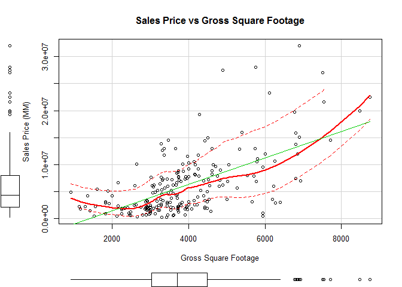

With the above chart we can clearly visualize the trend that we are seeing. It is very clear that there is a positive correlation between the gross square footage of a 1, 2, or 3 family home and the sales price.